# CourseProject

steven.zhang

October 25, 2015

# Background

Using devices such as Jawbone Up, Nike FuelBand, and Fitbit it is now possible to collect a large amount of data about personal activity relatively inexpensively. These type of devices are part of the quantified self movement – a group of enthusiasts who take measurements about themselves regularly to improve their health, to find patterns in their behavior, or because they are tech geeks. One thing that people regularly do is quantify how much of a particular activity they do, but they rarely quantify how well they do it. In this project, your goal will be to use data from accelerometers on the belt, forearm, arm, and dumbell of 6 participants. They were asked to perform barbell lifts correctly and incorrectly in 5 different ways. More information is available from the website here: http://groupware.les.inf.puc-rio.br/har (see the section on the Weight Lifting Exercise Dataset).

# Goal

The goal of your project is to predict the manner in which they did the exercise. This is the “classe” variable in the training set. You may use any of the other variables to predict with. You should create a report describing how you built your model, how you used *cross validation*, what you think *the expected out of sample error* is, and why you made the choices you did. You will also use your prediction model to predict 20 different test cases.

# Processing data

`loading data`

```r
set.seed(123123)
trainingURL <- "https://d396qusza40orc.cloudfront.net/predmachlearn/pml-training.csv"
testingURL <- "https://d396qusza40orc.cloudfront.net/predmachlearn/pml-testing.csv"
if(!file.exists("pml-training.csv"))
    download.file(trainingURL, destfile = "./pml-training.csv", method="curl")
if(!file.exists("pml-testing.csv"))
    download.file(testingURL, destfile = "./pml-testing.csv", method="curl")

training <- read.csv("pml-training.csv",header = TRUE,na.strings = c("NA","#DIV/0!",""))
testing <- read.csv("pml-testing.csv",header = TRUE,na.strings = c("NA","#DIV/0!",""))
```

`remove unused variables and NA obervation`

```r
require(caret)
nzv <- nearZeroVar(training)
training <- training[,-nzv]
testing <- testing[,-nzv]


rem <- colSums(is.na(training)) <=0.6*nrow(training)
training <- training[,rem]
testing <- testing[,rem]
```

### cross validation

```r
training <- training[,-c(1:7)]
testing <- testing[,-c(1:7)]

inTrain <- createDataPartition(y=training$classe,p=0.75,list=FALSE)
subtraining <- training[inTrain,]
subtesting <- training[-inTrain,]
```

### prediction with tree and random forest

```r
fit_rpart <- train(classe ~ .,method="rpart",data=subtraining)
predict_rpart <- predict(fit_rpart,subtesting)

library(rattle)
```

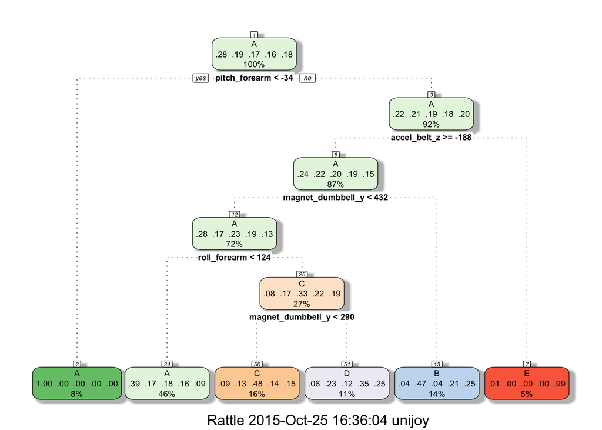

```r
fancyRpartPlot(fit_rpart$finalModel)
```

```r
confusionMatrix(predict_rpart,subtesting$classe)
```

```
## Confusion Matrix and Statistics
##
##           Reference
## Prediction    A    B    C    D    E
##          A 1272  367  395  331  202
##          B   27  336   28  164  206
##          C   66  101  379  136  124
##          D   30  144   53  173  124
##          E    0    1    0    0  245
##
## Overall Statistics
##
##                Accuracy : 0.4904
##                  95% CI : (0.4763, 0.5045)
##     No Information Rate : 0.2845
##     P-Value [Acc > NIR] : < 2.2e-16
##
##                   Kappa : 0.3345
##  Mcnemar's Test P-Value : < 2.2e-16
##
## Statistics by Class:
##
##                      Class: A Class: B Class: C Class: D Class: E
## Sensitivity            0.9118  0.35406  0.44327  0.21517  0.27192
## Specificity            0.6309  0.89254  0.89454  0.91439  0.99975
## Pos Pred Value         0.4955  0.44152  0.47022  0.33015  0.99593
## Neg Pred Value         0.9474  0.85204  0.88385  0.85594  0.85917
## Prevalence             0.2845  0.19352  0.17435  0.16395  0.18373
## Detection Rate         0.2594  0.06852  0.07728  0.03528  0.04996
## Detection Prevalence   0.5235  0.15518  0.16436  0.10685  0.05016
## Balanced Accuracy      0.7714  0.62330  0.66891  0.56478  0.63584
```

```r
library(randomForest)
fit_rf <- randomForest(classe ~ .,data=subtraining,method="class")
predict_rf <- predict(fit_rf,subtesting)
confusionMatrix(predict_rf,subtesting$classe)
```

```
## Confusion Matrix and Statistics
##
##           Reference
## Prediction    A    B    C    D    E
##          A 1394    3    0    0    0
##          B    1  945    5    0    0
##          C    0    1  848    5    1
##          D    0    0    2  799    1
##          E    0    0    0    0  899
##
## Overall Statistics
##
##                Accuracy : 0.9961
##                  95% CI : (0.994, 0.9977)
##     No Information Rate : 0.2845
##     P-Value [Acc > NIR] : < 2.2e-16
##
##                   Kappa : 0.9951
##  Mcnemar's Test P-Value : NA
##
## Statistics by Class:
##
##                      Class: A Class: B Class: C Class: D Class: E
## Sensitivity            0.9993   0.9958   0.9918   0.9938   0.9978
## Specificity            0.9991   0.9985   0.9983   0.9993   1.0000
## Pos Pred Value         0.9979   0.9937   0.9918   0.9963   1.0000
## Neg Pred Value         0.9997   0.9990   0.9983   0.9988   0.9995
## Prevalence             0.2845   0.1935   0.1743   0.1639   0.1837
## Detection Rate         0.2843   0.1927   0.1729   0.1629   0.1833
## Detection Prevalence   0.2849   0.1939   0.1743   0.1635   0.1833
## Balanced Accuracy      0.9992   0.9971   0.9950   0.9965   0.9989
```

## apply it to test data

```r
library(randomForest)
finalpreidiction <- predict(fit_rf,testing)
finalpreidiction
```

```
##  1  2  3  4  5  6  7  8  9 10 11 12 13 14 15 16 17 18 19 20
##  B  A  B  A  A  E  D  B  A  A  B  C  B  A  E  E  A  B  B  B
## Levels: A B C D E
```

```r
pml_write_files = function(x){
  n = length(x)
  for(i in 1:n){
    filename = paste0("problem_id_",i,".txt")
    write.table(x[i],file=filename,quote=FALSE,row.names=FALSE,col.names=FALSE)
  }
}
# pml_write_files(finalpreidiction)
```